# Лабораторная работа №12

Синхронизация времени

Устинова В. В.

Российский университет дружбы народов, Москва, Россия

14 ноября 2026

# Информация

## Докладчик

- Устинова Виктория Вадимовна
- студент НПИбд-01-24
- Российский университет дружбы народов

# Вводная часть

## Цель работы

Получение навыков по управлению системным временем и настройке синхронизации времени.

## Параметры времени на сервере

На сервере часовой пояс UTC, служба NTP активна, но системные часы не синхронизированы. Выведены системное время (`date`), аппаратное время (`hwclock`) и время в заданном формате.

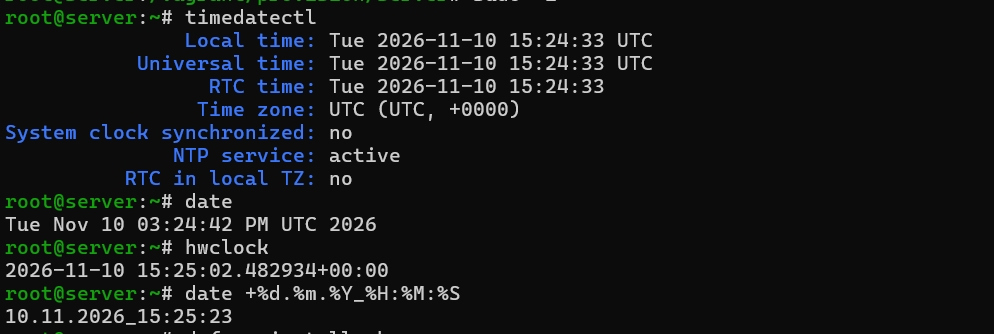

Параметры времени на сервере: timedatectl, date и hwclock

## Источники времени на сервере

Команда `chronyc sources` на сервере не выводит ни одной строки: внешних источников времени нет.

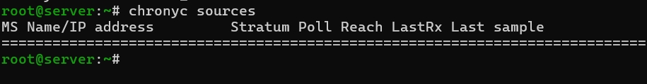

Список источников времени на сервере до настройки

## Параметры и источники на клиенте

На клиенте системные часы синхронизированы, `chronyc sources` показывает четыре внешних сервера. Звёздочка отмечает текущий источник, знак `+` — приемлемый, знак `-` — неиспользуемые. Reach 377 означает успешные последние опросы.

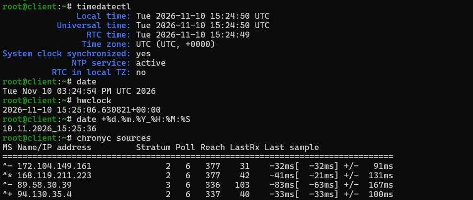

Параметры времени и источники времени на клиенте до настройки

## Настройка сервера

В `/etc/chrony.conf` добавлены `allow 192.168.0.0/16` и `local stratum 10`. После перезапуска chronyd в межсетевом экране разрешена служба ntp.

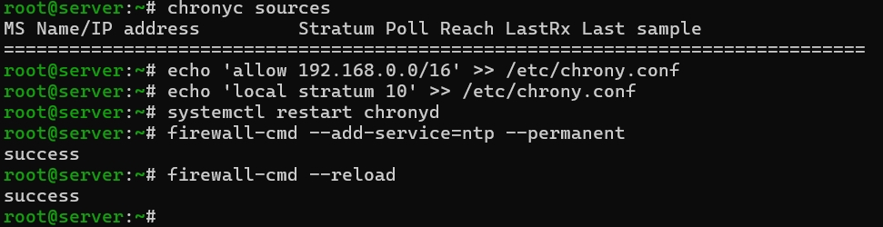

Настройка сервера как источника времени для локальной сети и межсетевого экрана

## Настройка клиента

На клиенте закомментированы директивы pool и server, добавлена строка `server server.vvustinova.net iburst`, chronyd перезапущен.

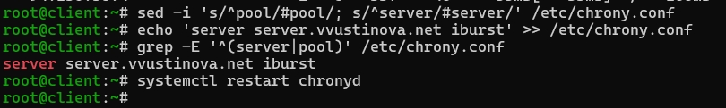

Настройка клиента: единственный источник времени — server.vvustinova.net

## Синхронизация на сервере

`chronyc tracking` на сервере показывает страту 10 и опорный источник 7F7F0101, то есть локальные часы. Файл `chrony.conf` скопирован в каталог provision.

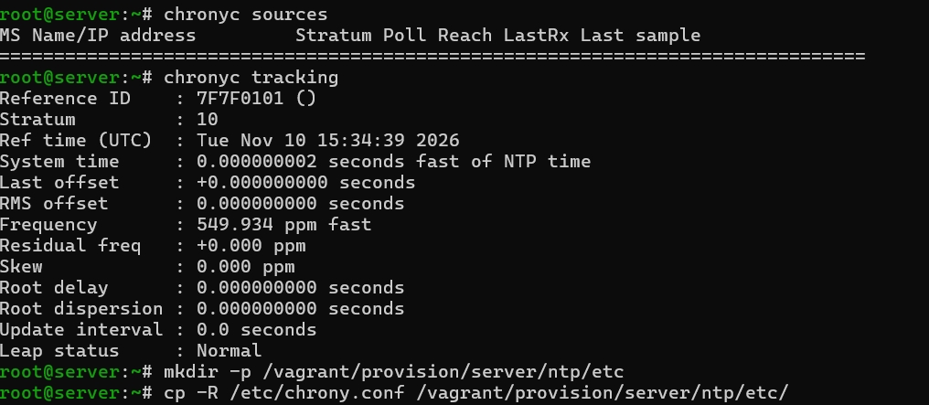

Информация о синхронизации на сервере и копирование chrony.conf в каталог provision

## Синхронизация на клиенте

Клиент синхронизирован с `server.vvustinova.net` (знак `*`, страта сервера 10). Страта клиента 11, то есть на единицу больше, опорный адрес 192.168.1.1.

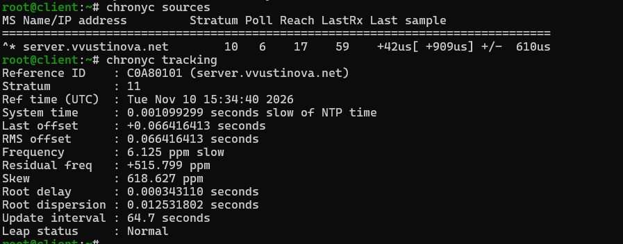

Источники времени и подробная информация о синхронизации на клиенте

## Скрипт ntp.sh для сервера

Скрипт устанавливает chrony, копирует конфигурацию, восстанавливает контексты SELinux, разрешает службу ntp и перезапускает chronyd.

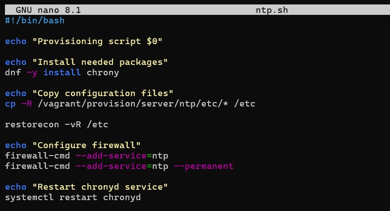

Скрипт ntp.sh виртуальной машины server

## Скрипт ntp.sh для клиента

Скрипт копирует конфигурацию chrony, восстанавливает контексты SELinux и перезапускает chronyd.

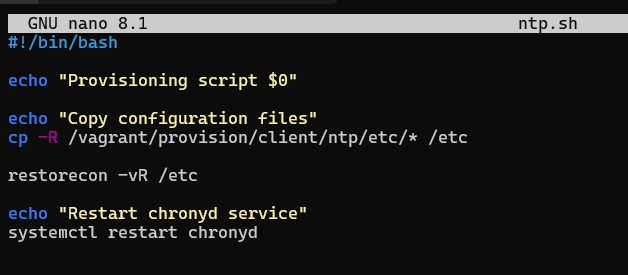

Скрипт ntp.sh виртуальной машины client

## Vagrantfile: сервер

В конфигурацию сервера добавлена запись provision «server ntp».

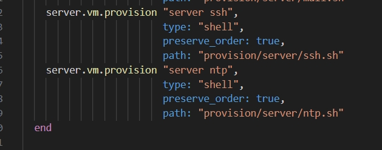

Запись server ntp в Vagrantfile

## Vagrantfile: клиент

В конфигурацию клиента добавлена запись provision «client ntp».

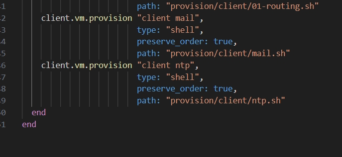

Запись client ntp в Vagrantfile

# Заключение